# IODS course project

Sergei Raik

# Introduction to Open Data Science - Course Project

# About the project

I wanted to gain some knowledge in data analysis for quite a long time. I found this course by simply surfing through list of courses with open registration date. This is an amazing opportunity to learn basics of up to date data analysis from experts.

The textbook is very well organized and easy to learn with. However it is always not so easy to digest the information about the tools you haven’t used yet.

## My github repository

https://github.com/SergeiRaik/IODS-project

```r
# This is a so-called "R chunk" where you can write R code.

date()
```

```
## [1] "Tue Nov 22 00:12:24 2022"
```

# Regression and model validation

## Introduction

This week I studied the regression models. Those are extremely important in data analysis as they bear several functions. They help us explain the relationship between variables and make a hypothesis how some parameters affect target variables. Another function is prediction. Using regression model we can predict unknown values of target variable by a set of explanatory vatiables. Here we used a dataset derived from 2014 year questionare aimed at identifying how various learning strategies (deep, surface and strategic) affect learning outcome (exam points).

## 1. Import the dataset from file.

```r
# import necessary packages
library(ggplot2)
library(dplyr)
library(GGally)
library(tidyverse)
#import dataset from file and set proper column types
learning2014 <- read_csv("data/learning2014.csv", col_types = cols(.default = "n", age = "i", gender = "f", points = "i"))
```

## 2. Dataset structure.

```r
str(learning2014) #stucture of the dataset
```

```
## spc_tbl_ [166 × 7] (S3: spec_tbl_df/tbl_df/tbl/data.frame)
##  $ gender  : Factor w/ 2 levels "F","M": 1 2 1 2 2 1 2 1 2 1 ...
##  $ age     : int [1:166] 53 55 49 53 49 38 50 37 37 42 ...
##  $ attitude: num [1:166] 3.7 3.1 2.5 3.5 3.7 3.8 3.5 2.9 3.8 2.1 ...
##  $ deep    : num [1:166] 3.58 2.92 3.5 3.5 3.67 ...
##  $ stra    : num [1:166] 3.37 2.75 3.62 3.12 3.62 ...
##  $ surf    : num [1:166] 2.58 3.17 2.25 2.25 2.83 ...
##  $ points  : int [1:166] 25 12 24 10 22 21 21 31 24 26 ...
##  - attr(*, "spec")=
##   .. cols(
##   ..   .default = col_number(),
##   ..   gender = col_factor(levels = NULL, ordered = FALSE, include_na = FALSE),
##   ..   age = col_integer(),
##   ..   attitude = col_number(),
##   ..   deep = col_number(),
##   ..   stra = col_number(),
##   ..   surf = col_number(),
##   ..   points = col_integer()
##   .. )
##  - attr(*, "problems")=<externalptr>
```

```r
dim(learning2014) # dimensions of the dataframe
```

```
## [1] 166   7
```

The dataset consists of 7 variables and 166 observations. The variable **gender**, which is 2 levels factor is respondents’ gender. Integers **age** and **points** are respondents’ age in years, and exam points respectively. Numerical variables **attitude**, **deep**, **stra**, and **surf** are derived from respondents’ answers and scaled to 0-5 points scale. More information on the data can be found [here](https://www.mv.helsinki.fi/home/kvehkala/JYTmooc/JYTOPKYS2-meta.txt). Briefly they represent three learning strategies (deep, surface and strategic) and general attitude towards statistics.

## 3. Overview of the data.

First let’s take a look on the summary of each variable.

```r
summary(learning2014) # dataframe summary
```

```
##  gender       age           attitude          deep            stra
##  F:110   Min.   :17.00   Min.   :1.400   Min.   :1.583   Min.   :1.250
##  M: 56   1st Qu.:21.00   1st Qu.:2.600   1st Qu.:3.333   1st Qu.:2.625
##          Median :22.00   Median :3.200   Median :3.667   Median :3.188
##          Mean   :25.51   Mean   :3.143   Mean   :3.680   Mean   :3.121
##          3rd Qu.:27.00   3rd Qu.:3.700   3rd Qu.:4.083   3rd Qu.:3.625
##          Max.   :55.00   Max.   :5.000   Max.   :4.917   Max.   :5.000
##       surf           points
##  Min.   :1.583   Min.   : 7.00
##  1st Qu.:2.417   1st Qu.:19.00
##  Median :2.833   Median :23.00
##  Mean   :2.787   Mean   :22.72
##  3rd Qu.:3.167   3rd Qu.:27.75
##  Max.   :4.333   Max.   :33.00
```

It can be seen that data related to learning strategies and attitude has the same range (0-5). The number of female participants is twice as high as male.

Let’s try to plot variables with each other and try to visually observe any correlation.

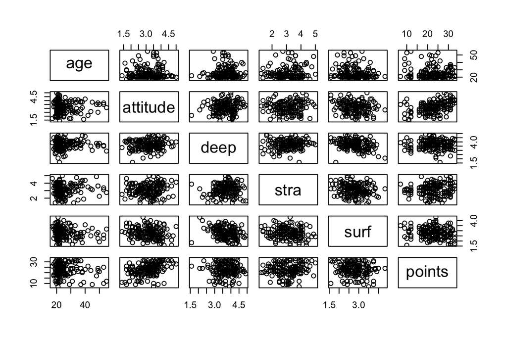

```r
pairs(learning2014[-1]) # plot every variable against each other excluding 1st column (gender)
```

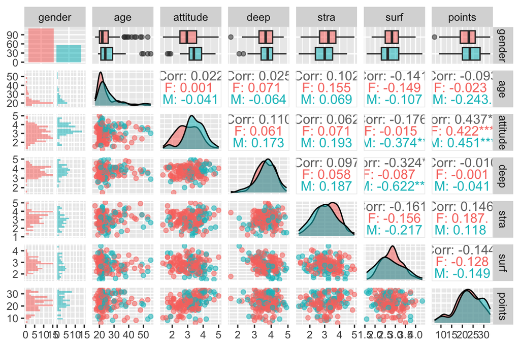

```r
# create a more advanced plot matrix with ggpairs()
ggpairs(learning2014, mapping = aes(alpha = 0.3, col = gender), lower = list(combo = wrap("facethist", bins = 20)))
```

From variables distribution graphs shape we can conclude that all of them except age have more or less symmetrical bell shape. To prove that let’s make a [QQ plot](https://www.statology.org/q-q-plot-normality/) for each variable. Simply said, QQ plot compares the distribution with the normal distribution. The graph should be linear if two normally distributed values are compares.

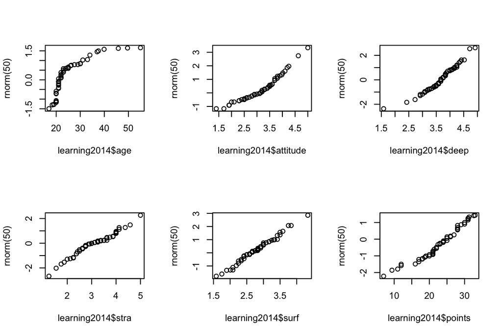

```r
par(mfrow = c(2,3)) # create a plot matrix
qqplot(learning2014$age # create a qq-plot for each variable to check if it is normally distributed
       , rnorm(50))
qqplot(learning2014$attitude
       , rnorm(50))
qqplot(learning2014$deep
       , rnorm(50))
qqplot(learning2014$stra
       , rnorm(50))
qqplot(learning2014$surf
       , rnorm(50))
qqplot(learning2014$points
       , rnorm(50))
```

Indeed, we can see that age is not normally distributed here. Other plots are linear.

## 4. Regression model

Let’s create a linear regression model where exam points are target variable and explanatory variables would be attitude, stra and surf, based on their correlation coefficients from previous section.

```r
# create a multivariable regression model
my_model <- lm(points ~ attitude + stra + surf, data = learning2014)
# create a model summary
summary(my_model)
```

```
##
## Call:
## lm(formula = points ~ attitude + stra + surf, data = learning2014)
##
## Residuals:
##      Min       1Q   Median       3Q      Max
## -17.1550  -3.4346   0.5156   3.6401  10.8952
##
## Coefficients:
##             Estimate Std. Error t value Pr(>|t|)
## (Intercept)  11.0171     3.6837   2.991  0.00322 **
## attitude      3.3952     0.5741   5.913 1.93e-08 ***
## stra          0.8531     0.5416   1.575  0.11716
## surf         -0.5861     0.8014  -0.731  0.46563
## ---
## Signif. codes:  0 '***' 0.001 '**' 0.01 '*' 0.05 '.' 0.1 ' ' 1
##
## Residual standard error: 5.296 on 162 degrees of freedom
## Multiple R-squared:  0.2074, Adjusted R-squared:  0.1927
## F-statistic: 14.13 on 3 and 162 DF,  p-value: 3.156e-08
```

From p-values we can conclude that the attitude has the highest influence on the target variable. stra and surf are insignificant. Therefore we can simplify the model to a single parameter without losing much predictability.

```r
# create a simplified model with single variable
my_model2 <- lm(points ~ attitude, data = learning2014)
# create a model summary
summary(my_model2)
```

```
##
## Call:
## lm(formula = points ~ attitude, data = learning2014)
##
## Residuals:
##      Min       1Q   Median       3Q      Max
## -16.9763  -3.2119   0.4339   4.1534  10.6645
##
## Coefficients:
##             Estimate Std. Error t value Pr(>|t|)
## (Intercept)  11.6372     1.8303   6.358 1.95e-09 ***
## attitude      3.5255     0.5674   6.214 4.12e-09 ***
## ---
## Signif. codes:  0 '***' 0.001 '**' 0.01 '*' 0.05 '.' 0.1 ' ' 1
##
## Residual standard error: 5.32 on 164 degrees of freedom
## Multiple R-squared:  0.1906, Adjusted R-squared:  0.1856
## F-statistic: 38.61 on 1 and 164 DF,  p-value: 4.119e-09
```

Indeed, the R-squared decreased roughly from 0.20 to 0.19. However both models are not very precise as they explain ~20 % of points variability. From the regression model it can be concluded that global attitude towards statistics positively correlates with exam outcome, however the influence is not very large.

## 5. Diagnostic plots

Let’s have a look at the plot of exam points vs attitude.

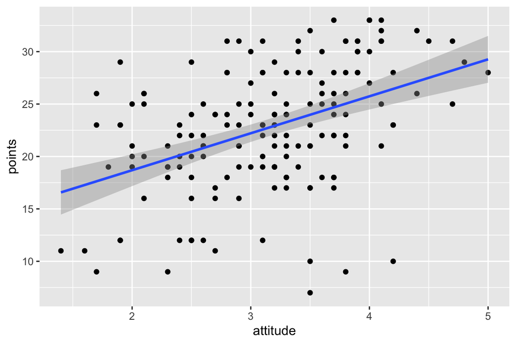

```r
qplot(attitude, points, data = learning2014) + geom_smooth(method = "lm") # points vs attitude linear plot
```

Our linear model suggests that there is linear relationship between exam points and general attitude towards statistics. To prove that we can make diagnostic plots.

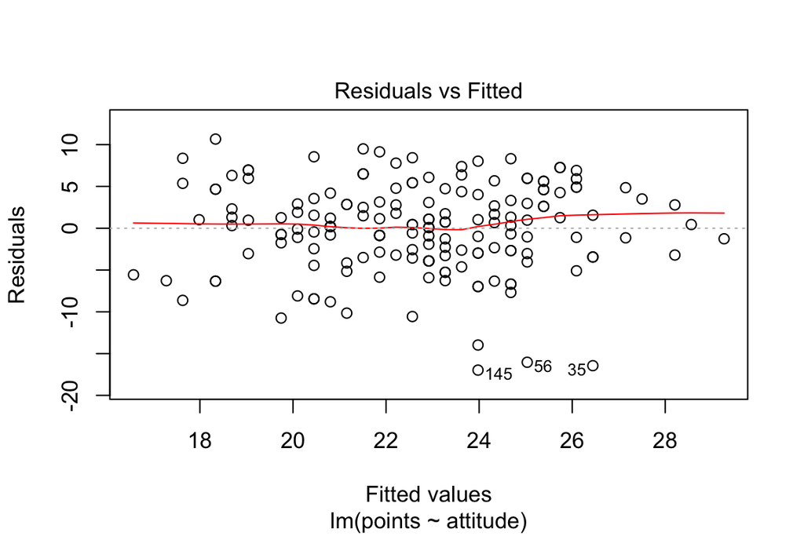

```r
plot(my_model2, which = 1) # residuals vs fitted
```

Residuals vs. fitted plot shows the difference between observed and fitted values. If the observed value equals exactly the predicted value, the residual value is zero. From our plot we can conclude that the assumption that the relationship is linear is reasonable as residuals are randomly distributed around the zero line. We can also observe values that do not fit the model: in observations 35, 56 and 145 students got unexpectedly low exam points despite their high attitude.

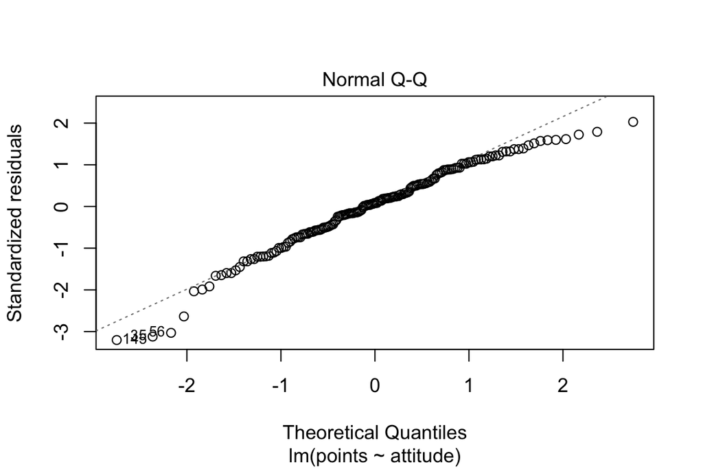

```r
plot(my_model2, which = 2) # QQ-plot
```

To check if the residuals are distributed normally, we made a QQ-plot where quantiles of residuals distribution are plotted against theoretical normal distribution quantiles. In our case the graph is fairly linear, however there is some deviation at its extremes.

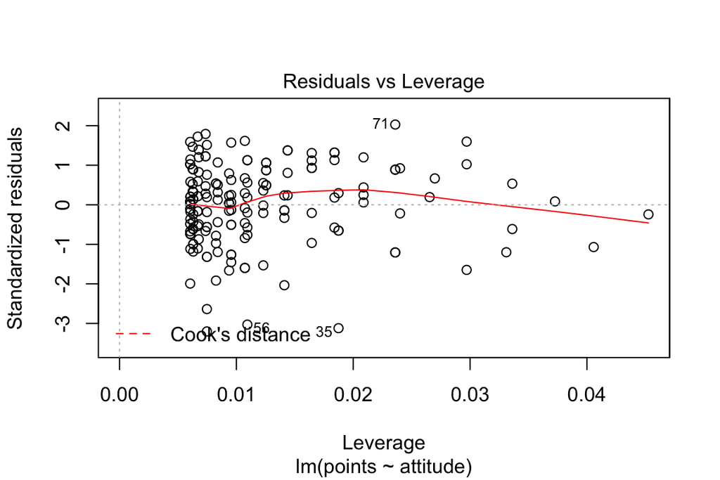

```r
plot(my_model2, which = 5) # residuals vs leverage plot
```

The Residuals vs Leverage plot shows us that none of the points fall outside the Cook’s distance, and therefore can not be considered influential observations.

# Logistic regression

## Introduction

This week we were working on a logistic regression. This is the method of estimation the relationships between categorical variables. This method is an extension of linear regression. The dataset we’ve been working with is describing student achievement in secondary education of two Portuguese schools. The dataset includes information regarding family status, school performance, spare time, alcohol consumption etc. The complete description is published on the [UCI Machine Learning Repository](https://archive.ics.uci.edu/ml/datasets/Student+Performance).

## 1. Dataset structure

Let’s import the wrangled dataset and take a look at it’s structure.

```r
# import necessary packages
library(ggplot2)
library(dplyr)
library(GGally)
library(tidyverse)

#import dataset from file and set proper column types
alc <- read_csv("data/alc.csv", show_col_types = FALSE, col_types = cols(.default = "f", age = "i", Medu = "i", Fedu = "i", traveltime = "i", studytime = "i", famrel = "i", freetime = "i", goout = "i", Dalc = "i", Walc = "i", health = "i", failures = "n", absences = "n", G1 = "n", G2 = "n", G3 = "n", alc_use = "n", high_use = "l"))

#check dataset structure, dimensions and column types
glimpse(alc)
```

```
## Rows: 370
## Columns: 35
## $ school     <fct> GP, GP, GP, GP, GP, GP, GP, GP, GP, GP, GP, GP, GP, GP, GP,…
## $ sex        <fct> F, F, F, F, F, M, M, F, M, M, F, F, M, M, M, F, F, F, M, M,…
## $ age        <int> 18, 17, 15, 15, 16, 16, 16, 17, 15, 15, 15, 15, 15, 15, 15,…
## $ address    <fct> U, U, U, U, U, U, U, U, U, U, U, U, U, U, U, U, U, U, U, U,…
## $ famsize    <fct> GT3, GT3, LE3, GT3, GT3, LE3, LE3, GT3, LE3, GT3, GT3, GT3,…
## $ Pstatus    <fct> A, T, T, T, T, T, T, A, A, T, T, T, T, T, A, T, T, T, T, T,…
## $ Medu       <int> 4, 1, 1, 4, 3, 4, 2, 4, 3, 3, 4, 2, 4, 4, 2, 4, 4, 3, 3, 4,…
## $ Fedu       <int> 4, 1, 1, 2, 3, 3, 2, 4, 2, 4, 4, 1, 4, 3, 2, 4, 4, 3, 2, 3,…
## $ Mjob       <fct> at_home, at_home, at_home, health, other, services, other, …
## $ Fjob       <fct> teacher, other, other, services, other, other, other, teach…
## $ reason     <fct> course, course, other, home, home, reputation, home, home, …
## $ guardian   <fct> mother, father, mother, mother, father, mother, mother, mot…
## $ traveltime <int> 2, 1, 1, 1, 1, 1, 1, 2, 1, 1, 1, 3, 1, 2, 1, 1, 1, 3, 1, 1,…
```

[output cut: 22 more lines]

The dataset consists of 35 variables and 370 observations.

## 2. Variables relationship hypotheses

**Hypothesis 1** People involved in romantic relationships are less likely to be heavy drinkers.

```r
alc %>% group_by(romantic,high_use) %>% summarise(count = n())
```

```
## # A tibble: 4 × 3
## # Groups:   romantic [2]
##   romantic high_use count
##   <fct>    <lgl>    <int>
## 1 no       FALSE      173
## 2 no       TRUE        78
## 3 yes      FALSE       86
## 4 yes      TRUE        33
```

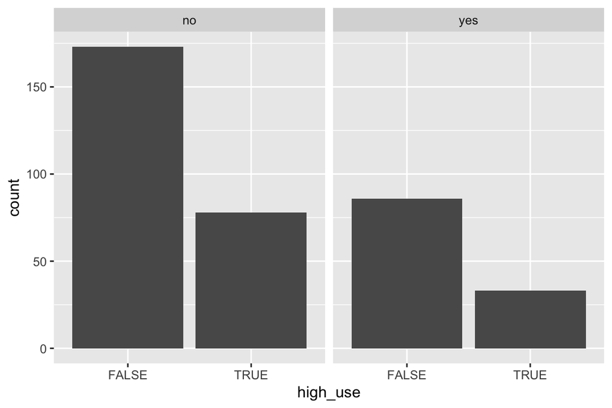

```r
g <- ggplot(data = alc, aes(x=high_use))
g+facet_wrap("romantic")+geom_bar()
```

**Hypothesis 2** People who go out with friends more often tend to drink more.

```r
# group by frequency of going out and alcohol coonsumption
alc %>% group_by(goout,high_use) %>% summarise(count = n())
```

```
## # A tibble: 10 × 3
## # Groups:   goout [5]
##    goout high_use count
##    <int> <lgl>    <int>
##  1     1 FALSE       19
##  2     1 TRUE         3
##  3     2 FALSE       82
##  4     2 TRUE        15
##  5     3 FALSE       97
##  6     3 TRUE        23
##  7     4 FALSE       40
##  8     4 TRUE        38
##  9     5 FALSE       21
## 10     5 TRUE        32
```

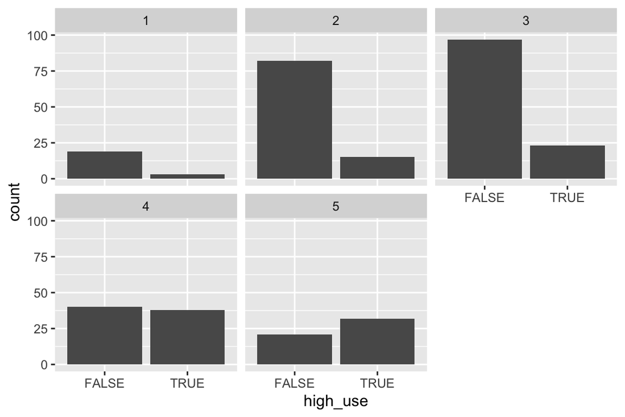

```r
g <- ggplot(data = alc, aes(x=high_use))
g+facet_wrap("goout")+geom_bar()
```

Indeed, it is clearly seen that those who go out with friends more often, tend to drink more.

**Hypothesis 3** People who spend more time studying, don’t have time for drinking.

```r
alc %>% group_by(studytime,high_use) %>% summarise(count = n())
```

```
## # A tibble: 8 × 3
## # Groups:   studytime [4]
##   studytime high_use count
##       <int> <lgl>    <int>
## 1         1 FALSE       56
## 2         1 TRUE        42
## 3         2 FALSE      128
## 4         2 TRUE        57
## 5         3 FALSE       52
## 6         3 TRUE         8
## 7         4 FALSE       23
## 8         4 TRUE         4
```

The correlation can be observed here as well. As you can see, within group of students who spend less than 2 hours for studying, there’s almost a half of “heavy drinkers”, whereas for those who study more than 10 hours, it decreases to ~14 %.

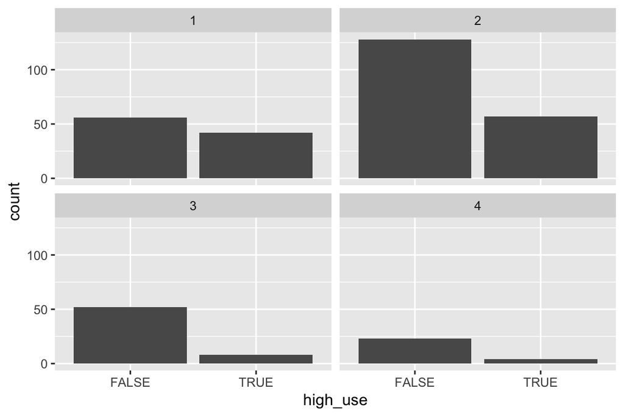

```r
g <- ggplot(data = alc, aes(x=high_use))
g+facet_wrap("studytime")+geom_bar()
```

**Hypothesis 4** People who consume large amounts of alcohol, have lower grades.

To analyze grades, we first take an average of three grades and then compare the distributions across groups of people who consume alcohol a lot and a bit.

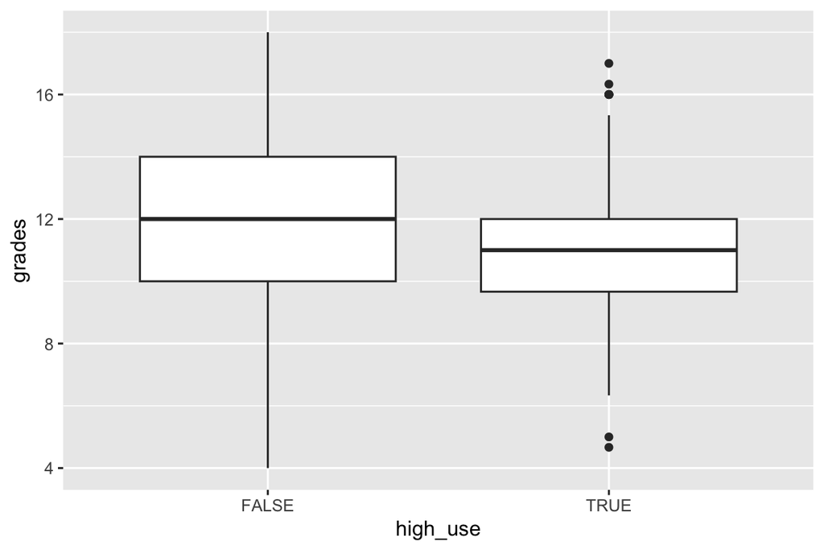

```r
alc$grades <- rowMeans(alc[, c("G1","G2","G3")])
g <- ggplot(data = alc, aes(x=high_use, y = grades))
g + geom_boxplot()
```

From boxplot graph it is not obvious whether alcohol consumption have an effect on grades. It seems that for low-drinkers the distribution is broader and the mean value is higher whereas for high-drinkers the distribution of grades is tilted towards lower values.

```r
alc %>% group_by(high_use) %>% summarise(mean(grades))
```

```
## # A tibble: 2 × 2
##   high_use `mean(grades)`
##   <lgl>             <dbl>
## 1 FALSE              11.8
## 2 TRUE               10.9
```

Mean values of grades differ not that much. Let’s take a look at each distribution separately.

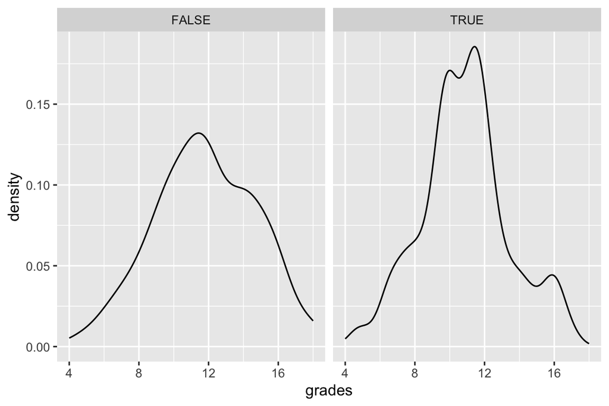

```r
g <- ggplot(data = alc, aes(x=grades))
g + geom_density(alpha=0.2)+facet_grid(~high_use)
```

## 3. Logistic regression model

To begin with we create a model of high_use as a target variable and those mentioned in the hypotheses section as explanatory variables (grades, studytime, goout, romantic),

```r
# create a logistic model and it's summary
m <- glm(high_use ~ grades + studytime + goout + romantic, data = alc, family = "binomial")
summary(m)
```

```
##
## Call:
## glm(formula = high_use ~ grades + studytime + goout + romantic,
##     family = "binomial", data = alc)
##
## Deviance Residuals:
##     Min       1Q   Median       3Q      Max
## -1.7852  -0.7805  -0.5395   0.9537   2.5739
##
## Coefficients:
##             Estimate Std. Error z value Pr(>|z|)
## (Intercept) -1.43474    0.73913  -1.941  0.05224 .
## grades      -0.05210    0.04664  -1.117  0.26400
## studytime   -0.58343    0.16813  -3.470  0.00052 ***
## goout        0.72552    0.11848   6.123 9.16e-10 ***
## romanticyes -0.19076    0.27253  -0.700  0.48396
## ---
## Signif. codes:  0 '***' 0.001 '**' 0.01 '*' 0.05 '.' 0.1 ' ' 1
##
## (Dispersion parameter for binomial family taken to be 1)
##
##     Null deviance: 452.04  on 369  degrees of freedom
## Residual deviance: 385.84  on 365  degrees of freedom
## AIC: 395.84
##
## Number of Fisher Scoring iterations: 4
```

```r
# compute odds ratios (OR)
OR <- coef(m) %>% exp

# compute confidence intervals (CI)
CI <- confint(m) %>% exp
# print out the odds ratios with their confidence intervals
cbind(OR, CI)
```

```
##                    OR      2.5 %    97.5 %
## (Intercept) 0.2381778 0.05452509 0.9971120
## grades      0.9492380 0.86558442 1.0397804
## studytime   0.5579787 0.39679174 0.7685481
## goout       2.0658027 1.64754827 2.6242897
## romanticyes 0.8263314 0.48042098 1.4021977
```

When the odds ratio is close to 1, it means that changing explanatory variable the odds of target variable does not change. Grades and romantic relationships with OR of 0.95 and 0.83 respectively do not correlate with alcohol consumption. Meanwhile each point of ‘goout’ variable doubles alcohol consumption odds. On the contrary each point of studytime decreases alcohol consumption odds by half.

## 4. Predictive power of the model

Let’s use our model for prediction of alcohol consumption level by calculating the probability of high_use with predict() function.

```r
#calculate the probabilities of high_use using logistic model
probabilities <- predict(m, type = "response")
alc <- mutate(alc, probability = probabilities)

#prediction is true if probability > 0.5
alc <- mutate(alc, prediction = probability>0.5)
alc %>% group_by(high_use,prediction) %>% summarise(count = n())
```

```
## # A tibble: 4 × 3
## # Groups:   high_use [2]
##   high_use prediction count
##   <lgl>    <lgl>      <int>
## 1 FALSE    FALSE        238
## 2 FALSE    TRUE          21
## 3 TRUE     FALSE         70
## 4 TRUE     TRUE          41
```

From the summarizing table we can conclude that when model predicts low level of alcohol consumption (FALSE), it is correct in 238 / (238 + 70) = 77 %. When high - 41 / (41 + 21) = 66 %. Overall the model prediction is wrong in (21 + 70) / (238 + 21 + 70 + 41) = 25 %. Overall if we compare the model with simple guessing strategy (0.5 % probability), it produces 25 % less wrong predictions which is not bad considering small number of variables taken.

(more chapters to be added similarly as we proceed with the course!)